# L08-E1-Multi Regression

## Exercise Instructions

- Complete all cells as instructed, replacing any ??? with the appropriate code
- Execute RStudio **Session** > **Restart & Run All Chunks** and ensure that all code blocks run without error

## Multivariate Regression Models

The model we created and evaluated in the prior exercise, was univariate or a **single regression model**. There is only one predictor or feature in a single regression model. However, most real-world regression problems have multiple features which can be used to train the model and predict the label. We call these models **multivariate regression models** or **multiple regression models**.

The extension from single regression to multiple regression is conceptually simple. As we add more features we add more model coefficients, one for each new feature. All of the model coefficients are estimated using **the method of least squared errors**. This is the same approach we used for our single regression model.

The R formula language is easily extended to multiple regression problems. For example, if we wish to predict a feature, `dv`, using two features, `var1` and `var2`, the model formula will be:

$$dv \sim var1 + var2$$

### Multiple regression example.

Let’s try an example of predicting the price of cars using an auto price data set. The data set contains the price of about 200 cars along with 25 attributes of each car.

**Note:** This data set is from the [University of California Irving Machine Learning Repository](https://archive.ics.uci.edu/ml/datasets/Automobile) The data was compiled by Jeffrey C. Schlimmer from the following sources:

- 1985 Model Import Car and Truck Specifications, 1985 Ward’s Automotive Yearbook.
- Personal Auto Manuals, Insurance Services Office, 160 Water Street, New York, NY 10038
- Insurance Collision Report, Insurance Institute for Highway Safety, Watergate 600, Washington, DC 20037 ***

As a first step we let’s read the data from the raw `.csv` file. The function below reads and prepares the data for exploration and analysis. Some data munging is required to prepare these data including:

1. The `.csv` file is read, with attention to the possible coding used for missing values in the raw file. Notice that several possible codings for missing values are enabled.
2. Replace the `-` character in the column names with `.`. The `-` character in a column name causes problems with R naming conventions.
3. Remove two unneeded columns and cases with missing data from the data frame using a dpyr verb pipeline. These verbs are chained by the %>% operator.

```r
read.auto = function(file = "auto_price.csv"){

    ## Read the raw csv file
  # Hint: read_csv
    auto.price <- read_csv (file, col_names = TRUE, na = c('?', '', NA))

    # remove the '-' character from the column names
    # Hint: names(), str_replace_all()
    names(auto.price) <- auto.price %>%
      names() %>%
      str_replace_all('-', '.')

    # Remove unwanted columns: symboling, normalized.losses
    # Remove the rows that have missing values
    # Hint: select(), complete.cases()
    auto.price <- auto.price %>%
                 select (-symboling, -normalized.losses)  %>%
                 filter( complete.cases (.))
    auto.price %>% head(5)
    # Convert character columns to factors
    # Hint: mutate_if(), is.character(), as.factor()
    auto.price <- auto.price %>%
      mutate_if ( is.character, as.factor )

    # Return the data frame
    # Hint: return()
    auto.price %>% return ()
}

# Call the read.auto() function and
# Store the results on auto.price
auto.price <- read.auto ()
# Explore the result
auto.price %>% glimpse()
```

```
Rows: 193
Columns: 24
$ make              <fct> alfa-romero, alfa-romero, alfa-romero, audi, audi, audi, audi, audi, audi, bmw, bmw, bmw, bmw, bmw, bmw, bmw, bmw, chevrolet, chevrolet…
$ fuel.type         <fct> gas, gas, gas, gas, gas, gas, gas, gas, gas, gas, gas, gas, gas, gas, gas, gas, gas, gas, gas, gas, gas, gas, gas, gas, gas, gas, gas, …
$ aspiration        <fct> std, std, std, std, std, std, std, std, turbo, std, std, std, std, std, std, std, std, std, std, std, std, std, turbo, std, std, std, s…
$ num.of.doors      <fct> two, two, two, four, four, two, four, four, four, two, four, two, four, four, four, two, four, two, two, four, two, two, two, four, fou…
$ body.style        <fct> convertible, convertible, hatchback, sedan, sedan, sedan, sedan, wagon, sedan, sedan, sedan, sedan, sedan, sedan, sedan, sedan, sedan, …
$ drive.wheels      <fct> rwd, rwd, rwd, fwd, 4wd, fwd, fwd, fwd, fwd, rwd, rwd, rwd, rwd, rwd, rwd, rwd, rwd, fwd, fwd, fwd, fwd, fwd, fwd, fwd, fwd, fwd, fwd, …
$ engine.location   <fct> front, front, front, front, front, front, front, front, front, front, front, front, front, front, front, front, front, front, front, fr…
$ wheel.base        <dbl> 88.6, 88.6, 94.5, 99.8, 99.4, 99.8, 105.8, 105.8, 105.8, 101.2, 101.2, 101.2, 101.2, 103.5, 103.5, 103.5, 110.0, 88.4, 94.5, 94.5, 93.7…
$ length            <dbl> 168.8, 168.8, 171.2, 176.6, 176.6, 177.3, 192.7, 192.7, 192.7, 176.8, 176.8, 176.8, 176.8, 189.0, 189.0, 193.8, 197.0, 141.1, 155.9, 15…
$ width             <dbl> 64.1, 64.1, 65.5, 66.2, 66.4, 66.3, 71.4, 71.4, 71.4, 64.8, 64.8, 64.8, 64.8, 66.9, 66.9, 67.9, 70.9, 60.3, 63.6, 63.6, 63.8, 63.8, 63.…
$ height            <dbl> 48.8, 48.8, 52.4, 54.3, 54.3, 53.1, 55.7, 55.7, 55.9, 54.3, 54.3, 54.3, 54.3, 55.7, 55.7, 53.7, 56.3, 53.2, 52.0, 52.0, 50.8, 50.8, 50.…
$ curb.weight       <dbl> 2548, 2548, 2823, 2337, 2824, 2507, 2844, 2954, 3086, 2395, 2395, 2710, 2765, 3055, 3230, 3380, 3505, 1488, 1874, 1909, 1876, 1876, 212…
$ engine.type       <fct> dohc, dohc, ohcv, ohc, ohc, ohc, ohc, ohc, ohc, ohc, ohc, ohc, ohc, ohc, ohc, ohc, ohc, l, ohc, ohc, ohc, ohc, ohc, ohc, ohc, ohc, ohc,…
$ num.of.cylinders  <fct> four, four, six, four, five, five, five, five, five, four, four, six, six, six, six, six, six, three, four, four, four, four, four, fou…
$ engine.size       <dbl> 130, 130, 152, 109, 136, 136, 136, 136, 131, 108, 108, 164, 164, 164, 209, 209, 209, 61, 90, 90, 90, 90, 98, 90, 90, 90, 122, 156, 92, …
$ fuel.system       <fct> mpfi, mpfi, mpfi, mpfi, mpfi, mpfi, mpfi, mpfi, mpfi, mpfi, mpfi, mpfi, mpfi, mpfi, mpfi, mpfi, mpfi, 2bbl, 2bbl, 2bbl, 2bbl, 2bbl, mpf…
$ bore              <dbl> 3.47, 3.47, 2.68, 3.19, 3.19, 3.19, 3.19, 3.19, 3.13, 3.50, 3.50, 3.31, 3.31, 3.31, 3.62, 3.62, 3.62, 2.91, 3.03, 3.03, 2.97, 2.97, 3.0…
$ stroke            <dbl> 2.68, 2.68, 3.47, 3.40, 3.40, 3.40, 3.40, 3.40, 3.40, 2.80, 2.80, 3.19, 3.19, 3.19, 3.39, 3.39, 3.39, 3.03, 3.11, 3.11, 3.23, 3.23, 3.3…
$ compression.ratio <dbl> 9.00, 9.00, 9.00, 10.00, 8.00, 8.50, 8.50, 8.50, 8.30, 8.80, 8.80, 9.00, 9.00, 9.00, 8.00, 8.00, 8.00, 9.50, 9.60, 9.60, 9.41, 9.40, 7.…
$ horsepower        <dbl> 111, 111, 154, 102, 115, 110, 110, 110, 140, 101, 101, 121, 121, 121, 182, 182, 182, 48, 70, 70, 68, 68, 102, 68, 68, 68, 88, 145, 58, …
$ peak.rpm          <dbl> 5000, 5000, 5000, 5500, 5500, 5500, 5500, 5500, 5500, 5800, 5800, 4250, 4250, 4250, 5400, 5400, 5400, 5100, 5400, 5400, 5500, 5500, 550…
$ city.mpg          <dbl> 21, 21, 19, 24, 18, 19, 19, 19, 17, 23, 23, 21, 21, 20, 16, 16, 15, 47, 38, 38, 37, 31, 24, 31, 31, 31, 24, 19, 49, 31, 38, 30, 30, 30,…
$ highway.mpg       <dbl> 27, 27, 26, 30, 22, 25, 25, 25, 20, 29, 29, 28, 28, 25, 22, 22, 20, 53, 43, 43, 41, 38, 30, 38, 38, 38, 30, 24, 54, 38, 42, 34, 34, 34,…
$ price             <dbl> 13495, 16500, 16500, 13950, 17450, 15250, 17710, 18920, 23875, 16430, 16925, 20970, 21105, 24565, 30760, 41315, 36880, 5151, 6295, 6575…
```

Examine the column names and data types printed above. Along with the label, `price`, there are a number of features. Some of these features appear useful, whereas, other do not.

### Exploring the data set

In this lesson we will not dive deeply into the exploratory analysis of these data. We will only examine aspects of the features we need to create a multiple regression model.

Our first exploration is to look at the distribution of the label and some of the numeric features. The code in the cell below plots the histogram and density estimate for each feature specified.

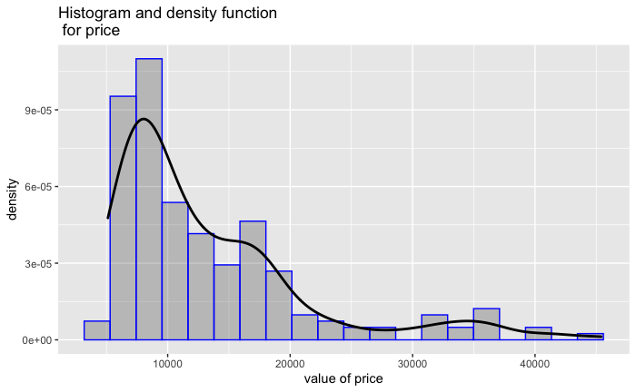

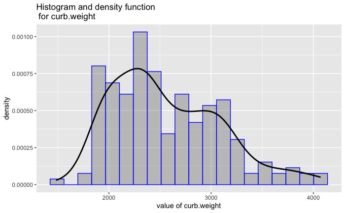

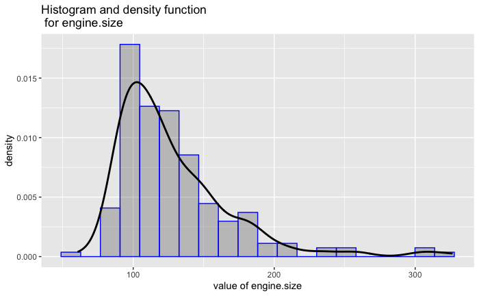

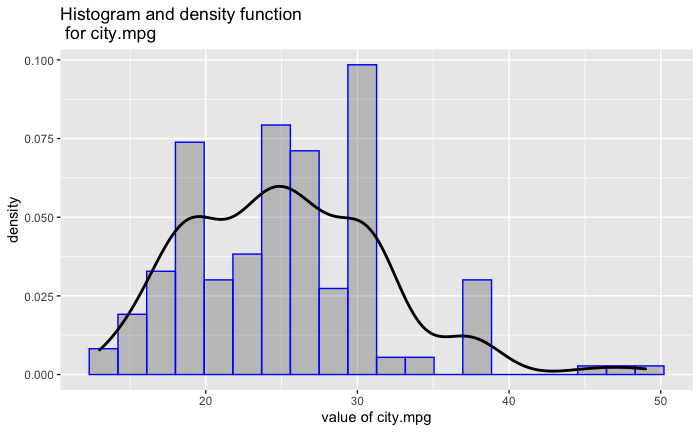

### Preparing and transforming data

It is common practice to try various **transformations** of variables to find better distributional properties. Examples of these transformations include logarithms, square roots, squares, exponentiation, and other power transformations.

In this case, we will preform a log transformation on the price and engine size. We will also try a square root transformation of engine price. These transformations are performed by the code in the cell below. Execute this code to compute the transformations and visualize the results.

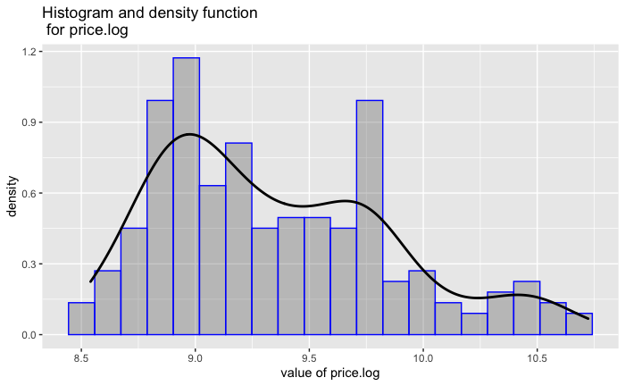

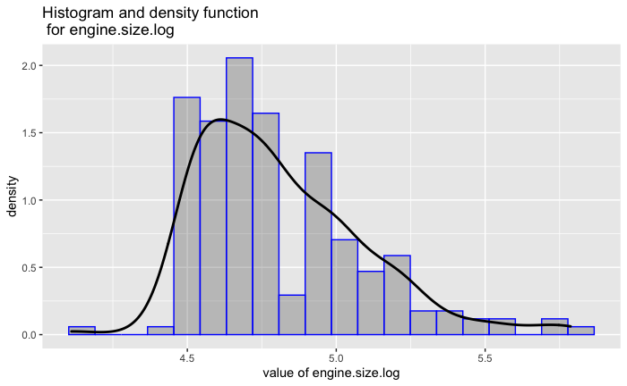

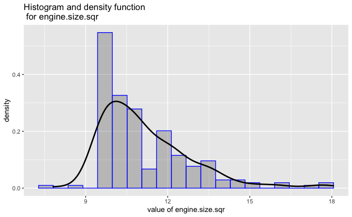

Examine these results. None of these distributions are ideal, but notice the following: 1. The log transformation of the price has resulted in a more symmetric distribution. 2. The log transformation of engine size appears more symmetric than the square root transformation or the raw variable.

Next, let’s briefly explore the relationship between some of these numeric features and the label, price. The code in the cell below creates plots for each of the features in the list vs. the log of price. Execute this code and examine the results.

**Programming note:** The code in the cell below is similar to the code you used to create the histograms. Compare this code with that used for the histograms, noticing the common recipe used for both. ***

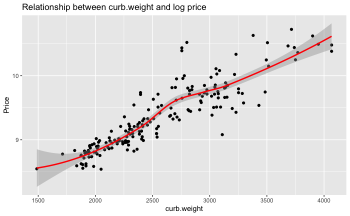

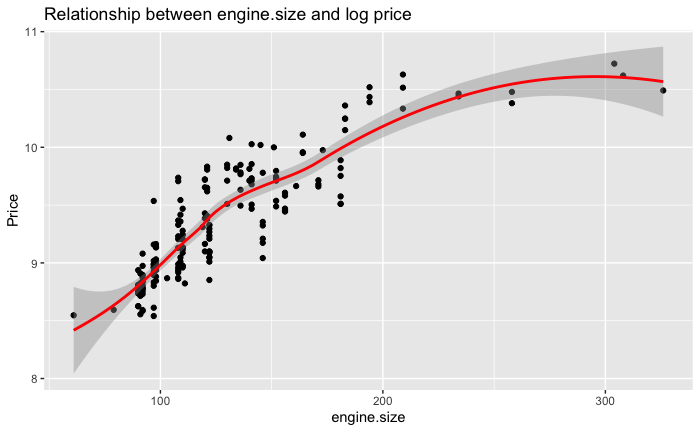

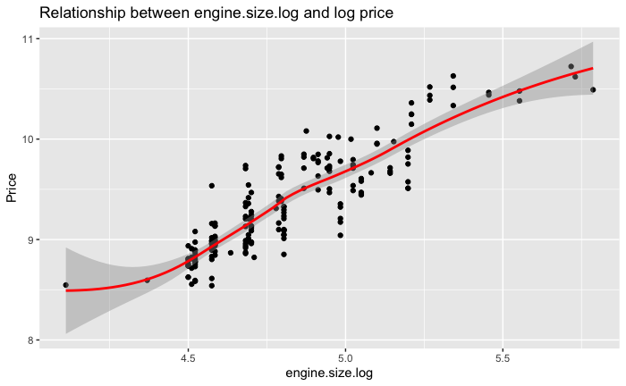

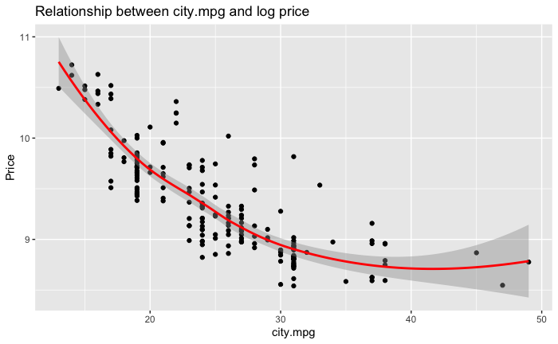

### Data normalization

Our next step is to **normalize** these numeric features. **Normalization is essential** whenever you are building a machine learning model with numeric features. If numeric features are not normalized the features with the largest numeric values can dominate the training of the model. In other words, the importance of features should not depend on the range of numeric values. Normalization addresses this problem.

In this case we will use a method known as **Zscore normalization**. Zscore normalization standardizes a feature so that it has **0 mean** and **unit (1.0) variance**. This process can be written for a feature vector, $x$, as:

$$x_{Zscore} = \frac{x - mean(x)}{sd(x)}\\
for\ a\ vector\ x$$

```r
normalize <- function(x) (x - mean(x))/sd(x)

# Calculate columns
# using the normalize function defined above
auto.price <- auto.price %>%
  mutate(curb.weight = normalize (curb.weight),
         engine.size = normalize(engine.size),
         engine.size.log = normalize(engine.size.log),
         city.mpg = normalize(city.mpg),
         city.mpg.sqr = normalize(city.mpg.sqr))

# Explore the result
auto.price %>%
  select(curb.weight, engine.size, engine.size.log, city.mpg, city.mpg.sqr) %>%
  glimpse() %>%
  summary()
```

```
Rows: 193
Columns: 5
$ curb.weight     <dbl> -0.02564604, -0.02564604, 0.49647278, -0.42625358, 0.49837140, -0.10348921, 0.53634368, 0.74519121, 0.99580824, -0.31613397, -0.31613397,…
$ engine.size     <dbl> 0.04509804, 0.04509804, 0.57406560, -0.45982555, 0.18936192, 0.18936192, 0.18936192, 0.18936192, 0.06914202, -0.48386953, -0.48386953, 0.…
$ engine.size.log <dbl> 0.20338747, 0.20338747, 0.76816827, -0.43306468, 0.36637945, 0.36637945, 0.36637945, 0.36637945, 0.23106865, -0.46635870, -0.46635870, 1.…
$ city.mpg        <dbl> -0.67729198, -0.67729198, -0.99038744, -0.20764880, -1.14693516, -0.99038744, -0.99038744, -0.99038744, -1.30348289, -0.36419653, -0.3641…
$ city.mpg.sqr    <dbl> -0.65723811, -0.65723811, -1.01480697, -0.15143612, -1.20065701, -1.01480697, -1.01480697, -1.01480697, -1.39174534, -0.31632809, -0.3163…
  curb.weight       engine.size      engine.size.log       city.mpg        city.mpg.sqr
 Min.   :-2.0382   Min.   :-1.6139   Min.   :-2.52996   Min.   :-1.9297   Min.   :-2.21911
 1st Qu.:-0.7908   1st Qu.:-0.7243   1st Qu.:-0.81735   1st Qu.:-0.9904   1st Qu.:-1.01481
 Median :-0.2801   Median :-0.1953   Median :-0.08576   Median :-0.0511   Median : 0.01005
 Mean   : 0.0000   Mean   : 0.0000   Mean   : 0.00000   Mean   : 0.0000   Mean   : 0.00000
 3rd Qu.: 0.7414   3rd Qu.: 0.4298   3rd Qu.: 0.62268   3rd Qu.: 0.7316   3rd Qu.: 0.77295
 Max.   : 2.8564   Max.   : 4.7577   Max.   : 3.52447   Max.   : 3.7060   Max.   : 3.20725
```

Our data set has now been prepared for building a multivariate linear regression model.

Before we get started building a model, let’s have a look at the transformed city mpg feature. Execute the code in the cell below to and examine the results.

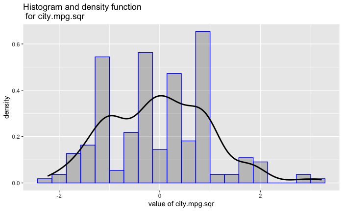

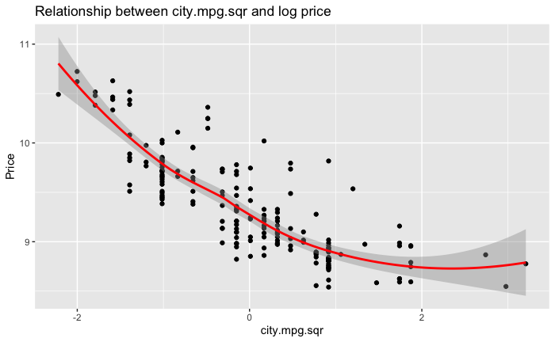

Compare these plots to the ones produced earlier. The distribution of the square root of city mpg is a bit more symmetric. The curvature with respect to the log of price is not that noticeably different.

### Training the model

With the data prepared, we can now create a linear regression model. The code in the cell below computes a linear regression model using 5 numeric features, both raw and computed. Execute this code and examine the printed the summary of the model.

**Note:** We are constructing a **linear model**. However, we have included features with nonlinear transformations. Thus, just because we are using a linear model does not mean we are limited to models of straight lines. ***

```r
auto.mod <- lm (price.log ~ curb.weight + engine.size + engine.size.log
              + city.mpg  + city.mpg.sqr, data = auto.price)

# View the model summary
# Hint: summary()
auto.mod %>% summary ()
```

```
Call:
lm(formula = price.log ~ curb.weight + engine.size + engine.size.log +
    city.mpg + city.mpg.sqr, data = auto.price)

Residuals:
     Min       1Q   Median       3Q      Max
-0.52935 -0.11275 -0.00619  0.10100  0.59043

Coefficients:
                Estimate Std. Error t value Pr(>|t|)
(Intercept)      9.35148    0.01393 671.462  < 2e-16 ***
curb.weight      0.21358    0.03287   6.498 7.18e-10 ***
engine.size     -0.13723    0.08026  -1.710 0.088945 .
engine.size.log  0.27443    0.08880   3.091 0.002303 **
city.mpg         0.78602    0.20999   3.743 0.000242 ***
city.mpg.sqr    -0.91257    0.21795  -4.187 4.35e-05 ***
---
Signif. codes:  0 ‘***’ 0.001 ‘**’ 0.01 ‘*’ 0.05 ‘.’ 0.1 ‘ ’ 1

Residual standard error: 0.1935 on 187 degrees of freedom
Multiple R-squared:  0.8605,    Adjusted R-squared:  0.8567
F-statistic: 230.6 on 5 and 187 DF,  p-value: < 2.2e-16
```

```r
# Print the confidence interval of the model coefficients
# Hint: confint()
cat('The coefficient confidence intervals')
```

```
The coefficient confidence intervals
```

```r
auto.mod %>% confint ()
```

```
                      2.5 %      97.5 %
(Intercept)      9.32400360  9.37895221
curb.weight      0.14873821  0.27841718
engine.size     -0.29555043  0.02109452
engine.size.log  0.09925717  0.44960542
city.mpg         0.37177507  1.20027394
city.mpg.sqr    -1.34252903 -0.48260919
```

Notice the following about these results: 1. The model appears to be **over-fit**, as the engine.size coefficient does not appear to be significant. 2. The residual standard error is reasonably small, given the range of label the log label values. 3. The adjusted R-squared is reasonable. 4. The model is significant.

### Evaluating model performance

Execute this code and compare the label values to the predicted values, along with the (log) residual values.

| price | price.log | engine.size.log | engine.size.sqr | city.mpg.sqr | score | resids | predicted.price |
| --- | --- | --- | --- | --- | --- | --- | --- |
| 13495 | 9.510075 | 0.2033875 | 11.40175 | -0.6572381 | 9.463035 | 0.04703977 | 12874.90 |
| 16500 | 9.711116 | 0.2033875 | 11.40175 | -0.6572381 | 9.463035 | 0.24808091 | 12874.90 |
| 16500 | 9.711116 | 0.7681683 | 12.32883 | -1.0148070 | 9.737158 | -0.02604202 | 16935.34 |
| 13950 | 9.543235 | -0.4330647 | 10.44031 | -0.1514361 | 9.179673 | 0.36356184 | 9697.98 |
| 17450 | 9.767095 | 0.3663794 | 11.66190 | -1.2006570 | 9.726643 | 0.04045242 | 16758.19 |
| 15250 | 9.632335 | 0.3663794 | 11.66190 | -1.0148070 | 9.551548 | 0.08078693 | 14066.45 |

Notice that for most cases the label (log label) values are close to the predicted (log predicted or score), and the residuals are small. In a few cases there are larger discrepancies and residuals.

The code in the cell below plots the (log) residuals. Execute this coded and examine the results.

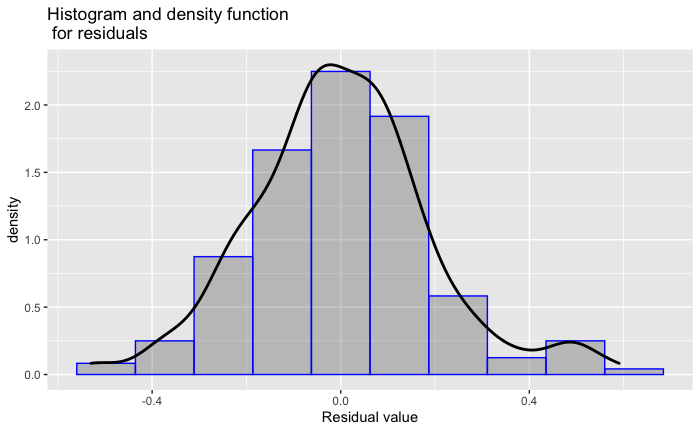

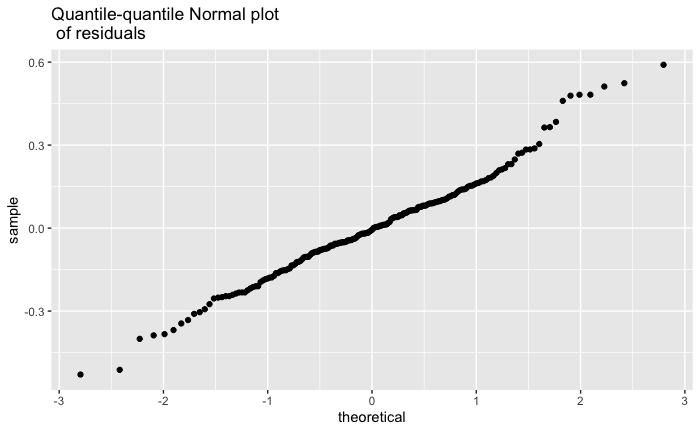

Examine these results. Notice that the residuals have some deviation from the ideal Normal, paticularly at the high end. This means that the price of certain autos are being significantly underestimated.

The code of in the cell below plots the residuals vs. the fitted values. Execute this code and examine the results.

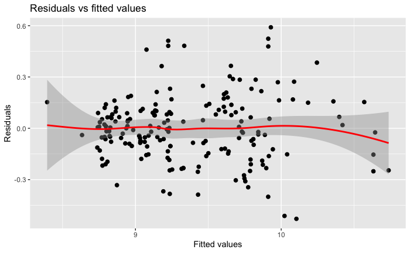

These residuals are appear fairly constant with the changes in (log) fitted values. The large positive residuals are visible in the middle of the range of fitted values. It appears that the predicted values of some higher priced cars are not being correctly predicted.

Overall, these results are not too bad, despite the over-fit model.

# Your turn:

We have established that the initial multiple regression model is over-fit. One or more features must to be pruned from the model. Typically, this is done by removing the features in order starting with the least significant, one at a time. For this exercise, prune the features until all of the remaining features are significant.

## Summary

In this lesson you have: - Evaluated the multiple regression model, to determine if the model is over-fit. - Explored and transformed the auto pricing data to prepare it for model building. - Explored and evaluated a multiple regression model for auto price.